# Exploratory-Data-Analysis

Andrew Lien

May 25, 2018

SECTIONS - CORRELATIONS TABLE - E. COLI VS DETERMINAND - TIME RELATIONSHIPS

Most important plots are plots 2c through 2i. These will likely be the ones that will be used to derive a predictive model.

## 1. CORRELATIONS TABLE

A correlation table gives a quick picture of whether there are correlations between any of the determinands and e. coli concentration. The table below shows that a linear model may not be the most effective predictive model. For that reason, each determinand is plotted against e. coli in section 2.

```r
cor.ecoli <- NULL
for(i in 5:length(water.raw.ecoli)){
  assign(x = paste("x", i, sep = "-"), value = cor(x = water.raw.ecoli[i], y = water.raw.ecoli$E.coli.C.MF.no.100ml, use = "complete.obs"))
  cor.ecoli <- rbind(cor.ecoli, get(paste("x", i, sep = "-")))
}
row.names(cor.ecoli) <- colnames(water.raw.ecoli[,5:length(water.raw.ecoli)])
cor.ecoli
```

```
##                             [,1]
## E.coli.C.MF.no.100ml  1.00000000
## Ammonia.N..mg.l       0.36450797
## COD.as.O2.mg.l        0.13353365
## Nitrate.N.mg.l       -0.03140521
## Nitrite.N.mg.l        0.06545345
## Oxygen.Diss.mg.l     -0.15459307
## pH.phunits           -0.05602240
## SALinsitu.ppt        -0.08248854
## Sld.Sus.105C.mg.l     0.06154314
## Temp.Water.cel        0.04285856
```

## 2. E. COLI VS DETERMINAND

Each determinand is plotted on the x-axis against the e. coli concentration on the y-axis. Points are grouped into either above (red) or below (blue) the water quality limit of 900 no/100mL.

### 2a. E. coli vs. Ammonia.N

No apparent relationship.

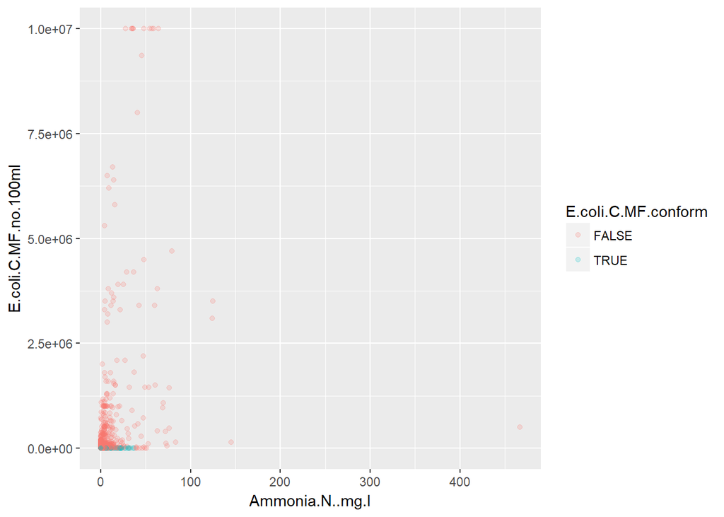

```r
ggplot(water.raw.ecoli, aes(x = `Ammonia.N..mg.l`, y = `E.coli.C.MF.no.100ml`, color = E.coli.C.MF.conform)) + geom_point(alpha = 0.2)
```

### 2b. E. coli vs. COD (chemical oxygen demand)

No apparent relationship.

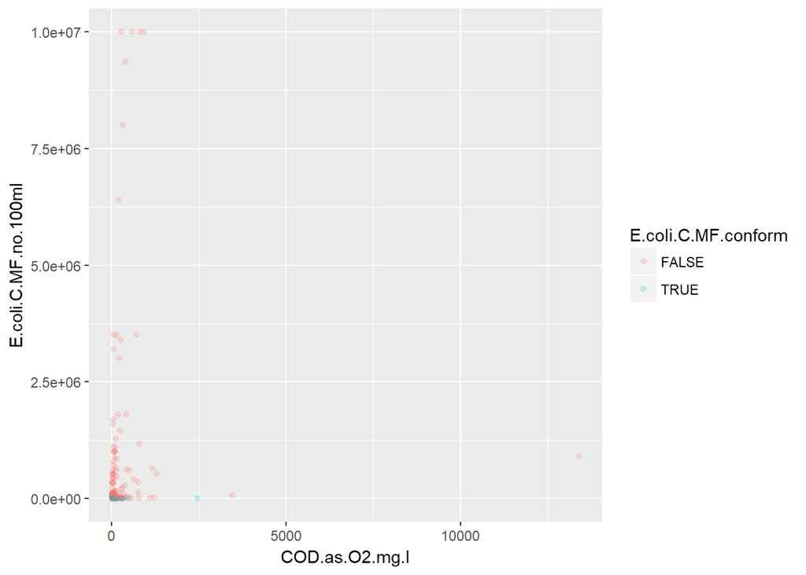

```r
ggplot(water.raw.ecoli, aes(x = `COD.as.O2.mg.l`, y = `E.coli.C.MF.no.100ml`, color = E.coli.C.MF.conform)) + geom_point(alpha = 0.2)
```

### 2c. E. coli vs. Nitrate.N

Slight exponential relationship, with more occurances of high e. coli concentrations at low concentration of Nitrate.N.

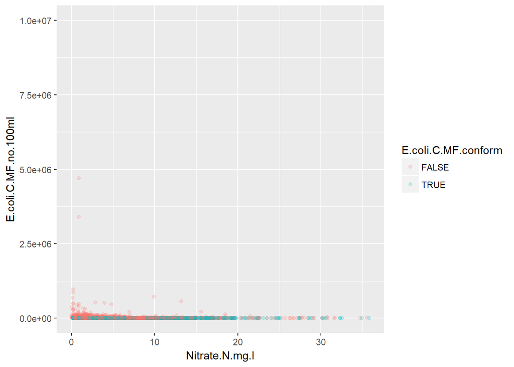

```r
ggplot(water.raw.ecoli, aes(x = `Nitrate.N.mg.l`, y = `E.coli.C.MF.no.100ml`, color = E.coli.C.MF.conform)) + geom_point(alpha = 0.2)
```

### 2d. E. coli vs. Nitrite.N

Slight exponential relationship.

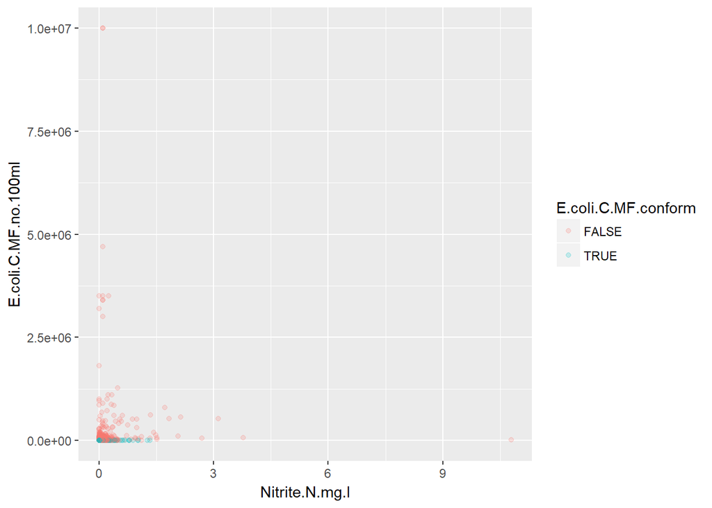

```r
ggplot(water.raw.ecoli, aes(x = `Nitrite.N.mg.l`, y = `E.coli.C.MF.no.100ml`, color = E.coli.C.MF.conform)) + geom_point(alpha = 0.2)
```

### 2e. E. coli vs. Dissolved Oxygen

Higher number of occurances of high e.coli at low oxygen dissolved amounts.

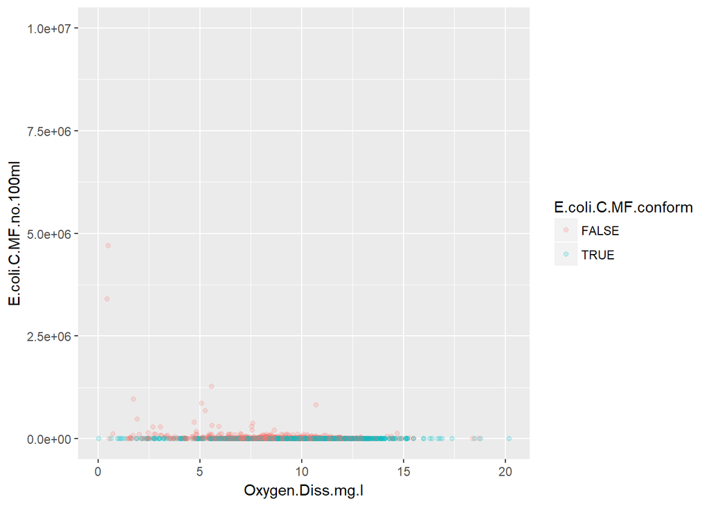

```r
ggplot(water.raw.ecoli, aes(x = `Oxygen.Diss.mg.l`, y = `E.coli.C.MF.no.100ml`, color = E.coli.C.MF.conform)) + geom_point(alpha = 0.2)
```

### 2f. E. coli vs. pH

```
## [1] "Negative-skewed normal distribution"
```

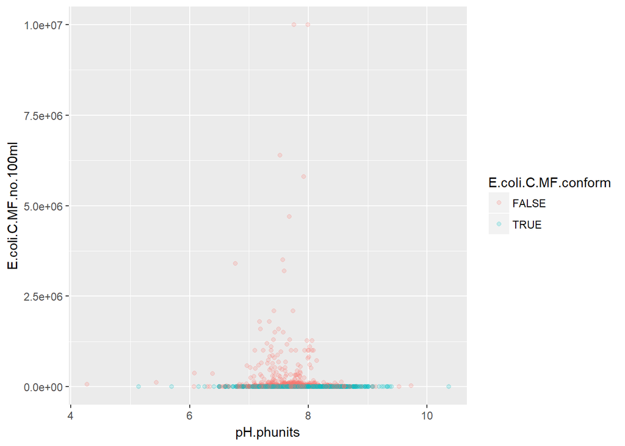

```r
ggplot(water.raw.ecoli, aes(x = `pH.phunits`, y = `E.coli.C.MF.no.100ml`, color = E.coli.C.MF.conform)) + geom_point(alpha = 0.2)
```

### 2g. E. coli vs. Salinity

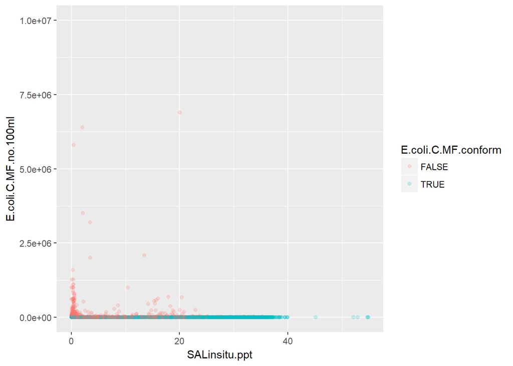

```r
ggplot(water.raw.ecoli, aes(x = `SALinsitu.ppt`, y = `E.coli.C.MF.no.100ml`, color = E.coli.C.MF.conform)) + geom_point(alpha = 0.2)
```

Exponential relationship.

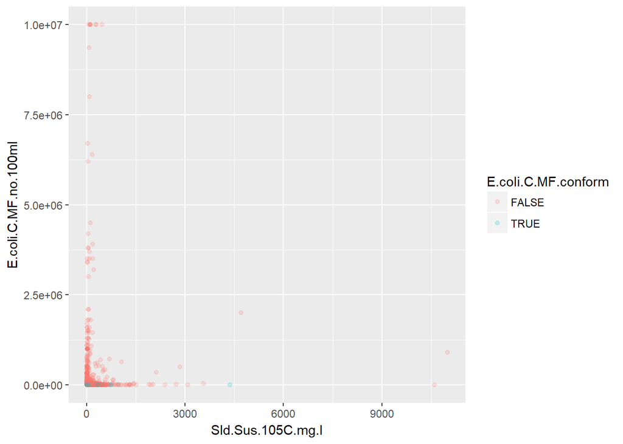

```r
ggplot(water.raw.ecoli, aes(x = `Sld.Sus.105C.mg.l`, y = `E.coli.C.MF.no.100ml`, color = E.coli.C.MF.conform)) + geom_point(alpha = 0.2)
```

### 2i. E. coli vs. Water Temperature

```
## [1] "Positively-skewed normal distribution"
```

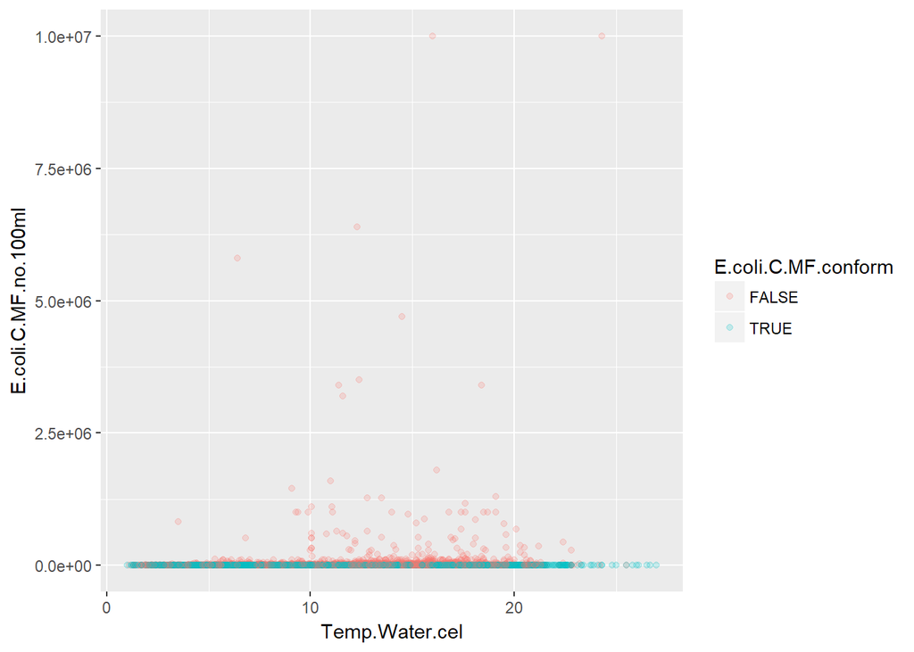

```r
ggplot(water.raw.ecoli, aes(x = `Temp.Water.cel`, y = `E.coli.C.MF.no.100ml`, color = E.coli.C.MF.conform)) + geom_point(alpha = 0.2)
```

## 3. TIME RELATIONSHIPS

### 3a. Time vs. e. coli

Increased number of occurences of high concentrations of e. coli in summers.

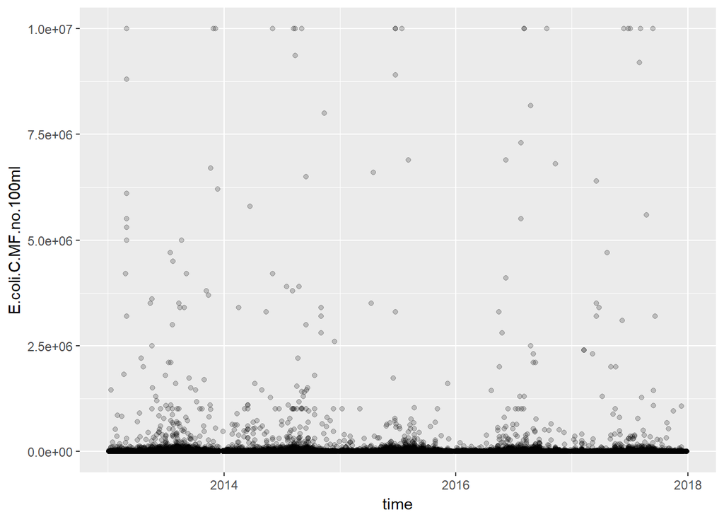

```r
ggplot(water.raw.ecoli, aes(x = time, y = `E.coli.C.MF.no.100ml`)) + geom_point(alpha = 0.2)
```

### 3b. Time vs. Water temperature

Water is warmer in summer. Self-evident.

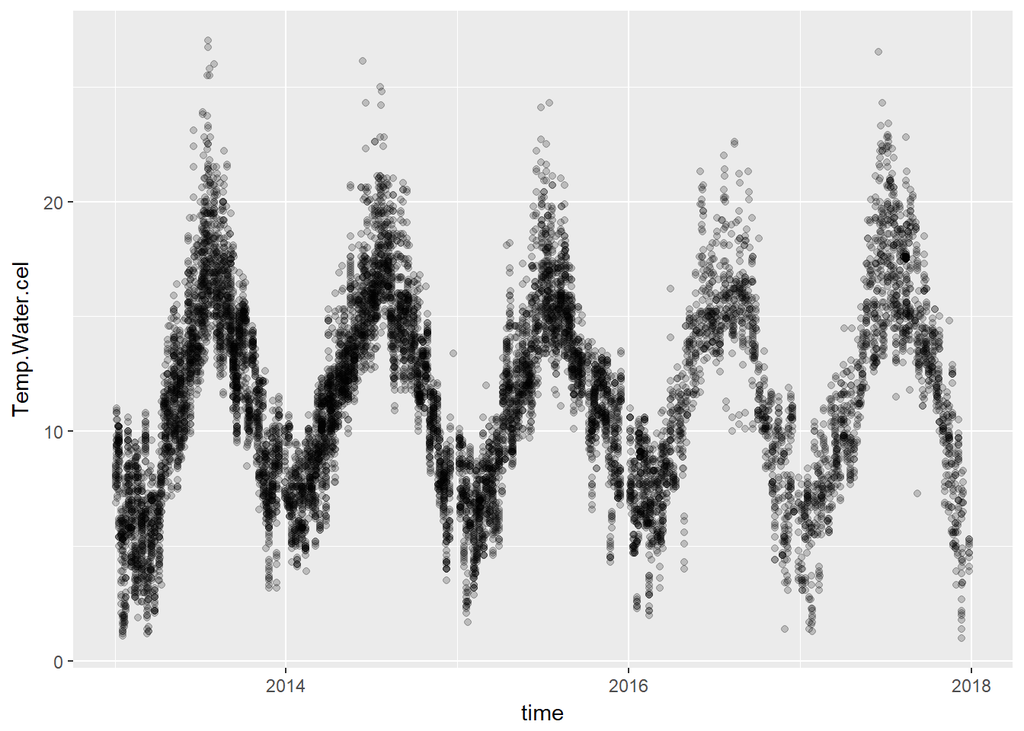

```r
ggplot(water.raw.ecoli, aes(x = time, y = `Temp.Water.cel`)) + geom_point(alpha = 0.2)
```

### 3c. Time vs Dissolved Oxygen

Fluctuates with season as expected, higher in winter and lower in summer. Liquids can carry more dissolved gasses at lower temperature.

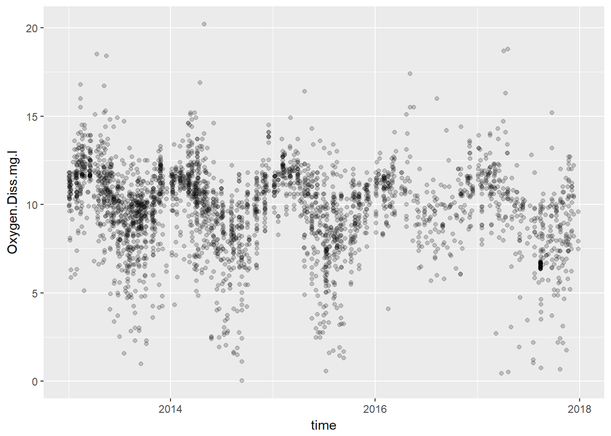

```r
ggplot(water.raw.ecoli, aes(x = time, y = `Oxygen.Diss.mg.l`)) + geom_point(alpha = 0.2)
```

### 3d. Time vs. salinity

Measured far more often in summers.

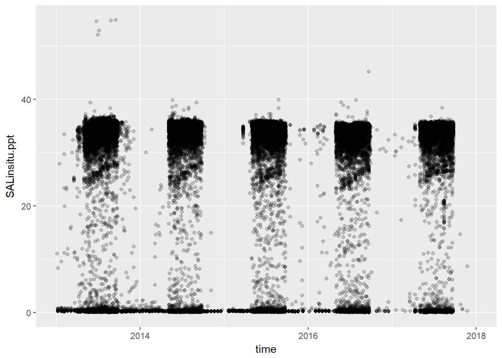

```r
ggplot(water.raw.ecoli, aes(x = time, y = `SALinsitu.ppt`)) + geom_point(alpha = 0.2)
```

### 3e. Time vs Solids Suspended at 105 C

No obvious relationship, other than the fact that most points that are above a certain value in solids suspended also happen to have e. coli concentrations above water quality standards.

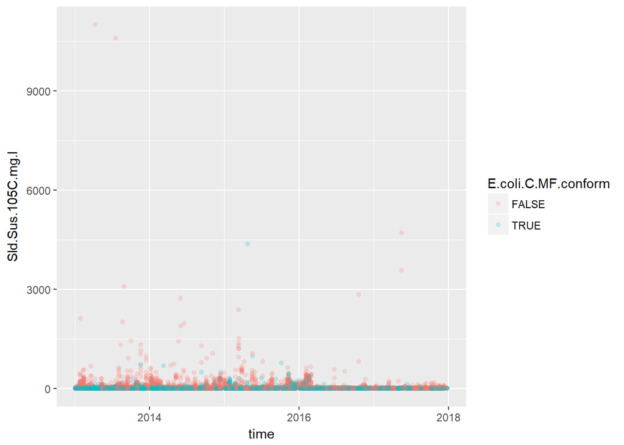

```r
ggplot(water.raw.ecoli, aes(x = time, y = `Sld.Sus.105C.mg.l`, color = E.coli.C.MF.conform)) + geom_point(alpha = 0.2)
```